# Hayman Fire Recovery

Alex Siggers

02 February, 2022

## Question 1)

What is the correlation between NDVI and NDMI? - here I want you to convert the full_long dataset in to a wide dataset using the function “spread” and then make a plot that shows the correlation s a function of if the site was burned or not (x axis should be ndmi) You should exclude winter months and focus on summer months

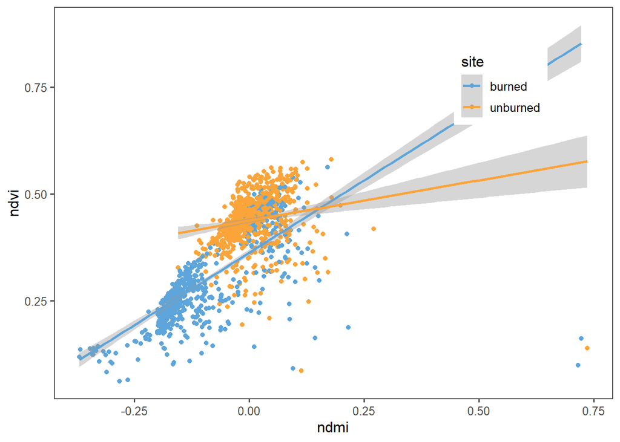

#There appears to be a positive correlation between precipitation and vegetation in the summer months.

## Question 2

2. What is the correlation between average NDSI (normalized snow index) for January - April and average NDVI for June-August? In other words, does the previous year’s snow cover influence vegetation growth for the following summer?

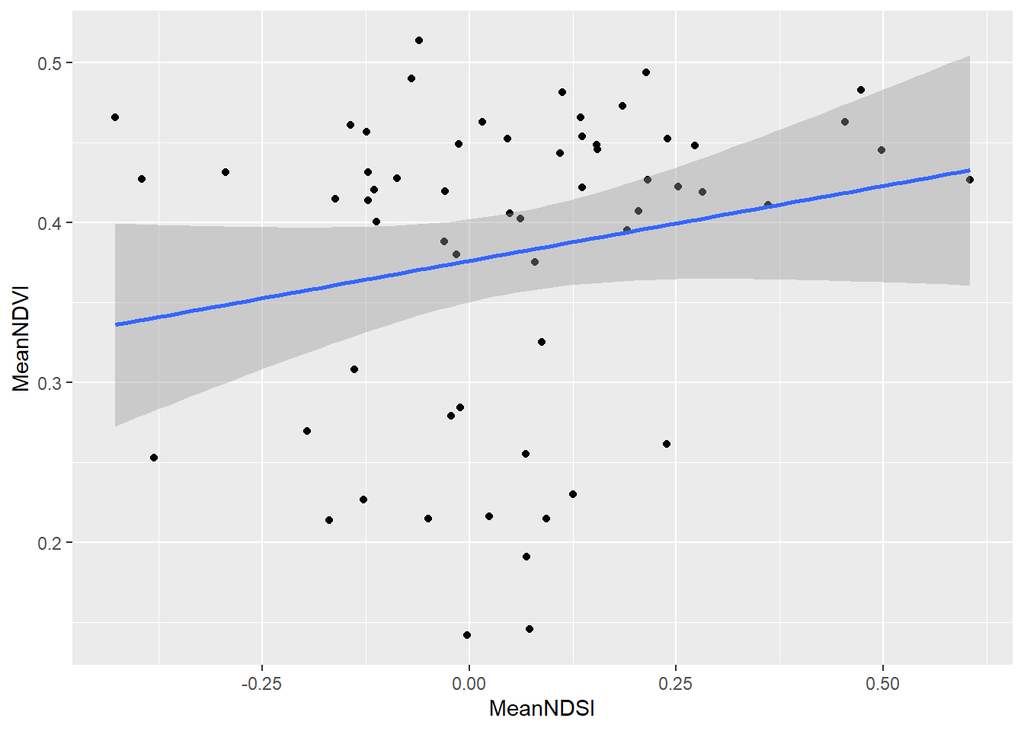

#After taking averages and fitting to a linear model, it appears that there is a slightly positive correlation.

## Q3

How is the snow effect from question 2 different between pre- and post-burn and burned and unburned?

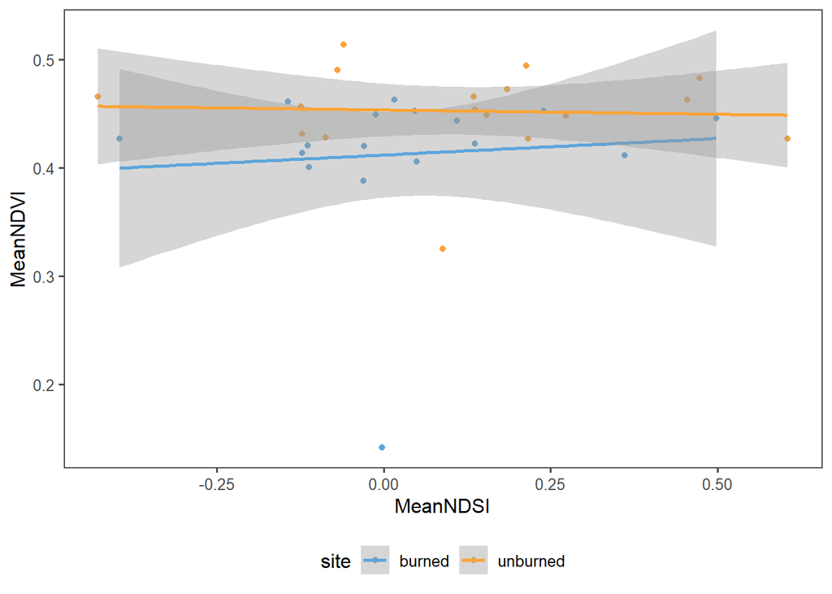

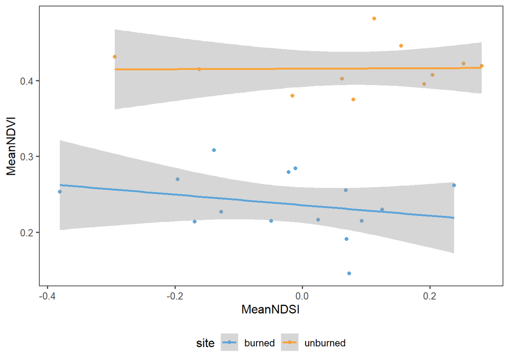

## Question 4

What month is the greenest month on average?

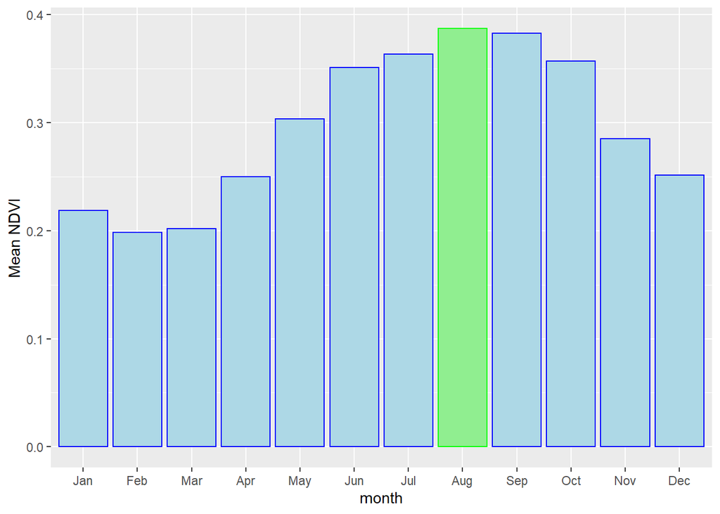

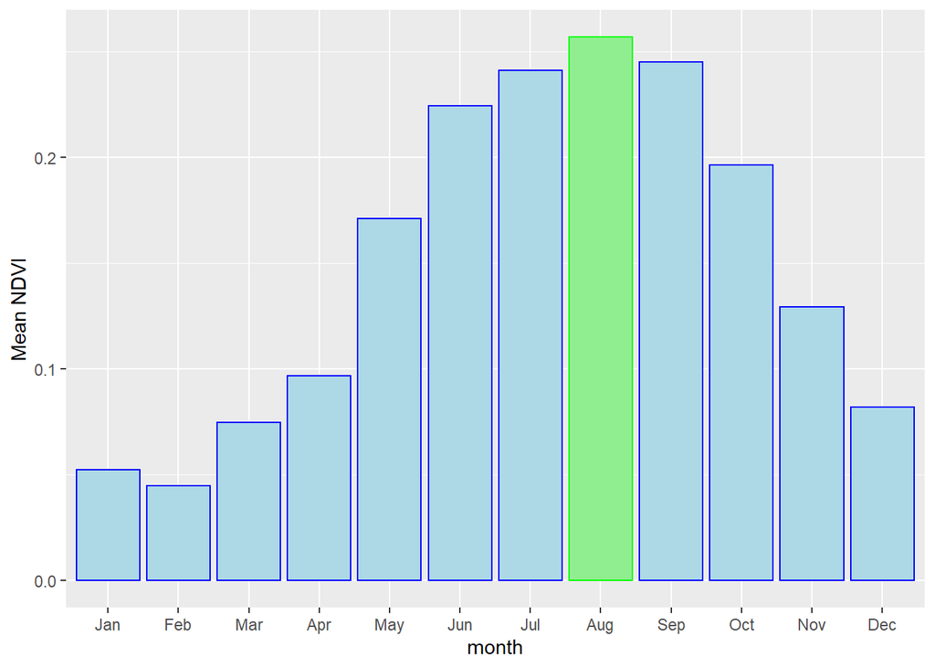

#August is the greenest month across all plots and remains so in burned plots following the fire.

## Question 5)

What month is the snowiest on average?

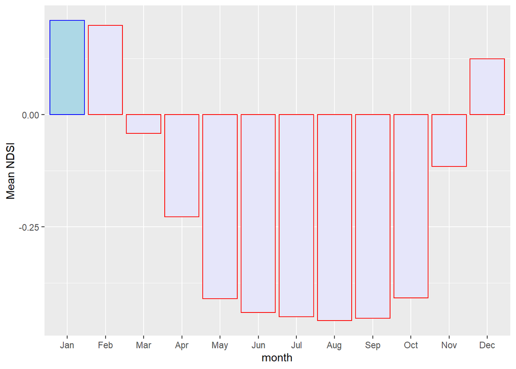

January is the snowiest month on average.